# R practical Survival Analysis

```r
library(survival)
library(survminer)
library(readxl)
mac <- read_excel("HSDA_mac.xlsx")
str(mac)
```

```
## tibble [1,177 x 27] (S3: tbl_df/tbl/data.frame)
##  $ patid      : num [1:1177] 1 2 3 4 5 6 7 8 9 10 ...
##  $ age        : num [1:1177] 42 33 39 35 42 45 26 33 45 40 ...
##  $ agecat     : num [1:1177] 1 0 1 0 1 1 0 0 1 1 ...
##  $ sex        : num [1:1177] 0 0 0 0 0 0 0 0 0 0 ...
##  $ karnof     : num [1:1177] 90 90 100 80 90 90 90 90 80 60 ...
##  $ ivdrug     : num [1:1177] 0 0 0 0 0 0 0 0 0 1 ...
##  $ antiret    : num [1:1177] 1 0 1 0 0 0 0 1 1 0 ...
##  $ cd4        : num [1:1177] 8 30 80 58 59 18 20 30 30 20 ...
##  $ cd4cat     : num [1:1177] 0 1 1 1 1 0 0 1 1 0 ...
##  $ ctg        : num [1:1177] 1 1 1 1 1 1 1 1 1 1 ...
##  $ dthstat    : num [1:1177] 0 0 1 0 0 1 1 1 0 1 ...
##  $ dthtime    : num [1:1177] 623 651 464 622 643 216 425 449 811 74 ...
##  $ macstat    : num [1:1177] 1 0 0 0 0 0 1 1 1 0 ...
##  $ mactime    : num [1:1177] 560 651 26 622 643 171 174 449 377 58 ...
##  $ swdrstat   : num [1:1177] 1 1 0 1 1 0 1 1 0 0 ...
##  $ swdrtime   : num [1:1177] 106 86 26 111 119 171 163 260 28 74 ...
##  $ rif        : num [1:1177] 1 1 1 0 0 0 0 1 0 1 ...
##  $ clari      : num [1:1177] 0 0 0 1 1 1 0 0 0 0 ...
##  $ toxstat    : num [1:1177] 0 0 0 0 0 1 0 1 1 0 ...
##  $ toxtime    : num [1:1177] 623 651 26 501 643 171 230 422 28 74 ...
##  $ sexarv     : num [1:1177] 0 0 0 0 0 0 0 0 0 0 ...
##  $ antibiotic : num [1:1177] 1 1 1 2 2 2 3 1 3 1 ...
##  $ dthtime.m  : num [1:1177] 21 22 15 21 21 7 14 15 27 2 ...
##  $ dthtime_1m : num [1:1177] 22 23 16 22 22 8 15 16 28 3 ...
##  $ sam.date   : POSIXct[1:1177], format: "1993-10-03" "1993-09-27" ...
##  $ dthtimedate: POSIXct[1:1177], format: "1995-06-18" "1995-07-10" ...
##  $ onstudydate: POSIXct[1:1177], format: "1993-10-03" "1993-09-27" ...
```

MAC (Mycobacterium avium complex) prophylaxis study

- Phase III randomized, double-blind study comparing rifabutin, clarithromycin, and the combination of rifabutin and clarithromycin for prevention of MAC disease in HIV-infected patients with CD4 lymphocyte counts < 100 cells/μL.
- N=1177 patients were accrued over an 8-month period and randomized in equal proportions to the three treatment arms. Patients were followed for a median of 19 months (the study closed in August 1995, prior to the advent of widespread use of protease inhibitors)

Variables of interest:

dthstat : Status

dthtime_1m : time

age

cd4 : CD4 cells/mL

antibiotic: clarithromycin,rifabutin,combination

sex 0: Males, 1:Females

antiret : Antiretroviral experience = Never or unknown=0, Current/previous use=1

```r
# transform to factors:
mac$antibiotic<-factor(mac$antibiotic,levels = c(1,2,3),labels=c("rifabutin","clarithromycin","combination"))
mac$antiret <- factor(mac$antiret, levels=c(0,1), labels=c("No", "Yes"))
```

# Univariate Cox regression models

```r
# categorical variable - sex
mac$sex <- as.factor(mac$sex)
coxmac_sex <- coxph(Surv(dthtime_1m, dthstat) ~ sex, data = mac)
summary(coxmac_sex)
```

```
## Call:
## coxph(formula = Surv(dthtime_1m, dthstat) ~ sex, data = mac)
##
##   n= 1177, number of events= 514
##
##        coef exp(coef) se(coef)    z Pr(>|z|)
## sex1 0.2252    1.2526   0.1453 1.55    0.121
##
##      exp(coef) exp(-coef) lower .95 upper .95
## sex1     1.253     0.7983    0.9422     1.665
##
## Concordance= 0.51  (se = 0.007 )
## Likelihood ratio test= 2.27  on 1 df,   p=0.1
## Wald test            = 2.4  on 1 df,   p=0.1
## Score (logrank) test = 2.41  on 1 df,   p=0.1
```

Interpretation: The hazard of death does not differ significantly between males and females.

```r
# comparison with log-rank test
survdiff(Surv(dthtime_1m, dthstat) ~ sex, data = mac)
```

```
## Call:
## survdiff(formula = Surv(dthtime_1m, dthstat) ~ sex, data = mac)
##
##          N Observed Expected (O-E)^2/E (O-E)^2/V
## sex=0 1060      461    470.7     0.199      2.44
## sex=1  117       53     43.3     2.160      2.44
##
##  Chisq= 2.4  on 1 degrees of freedom, p= 0.1
```

We notice that similar results are obtained.

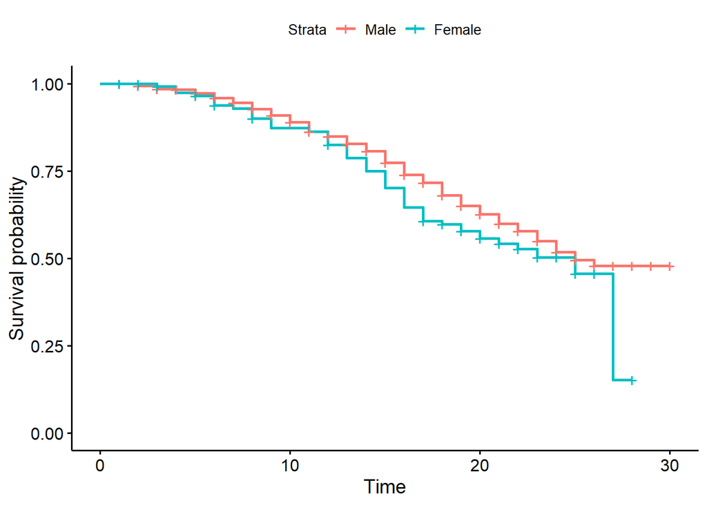

```r
# Kaplan Meier Curve for Sex
sex.km <- survfit(Surv(dthtime_1m, dthstat) ~ sex, data = mac)
ggsurvplot(sex.km, legend.labs=c("Male", "Female"))
```

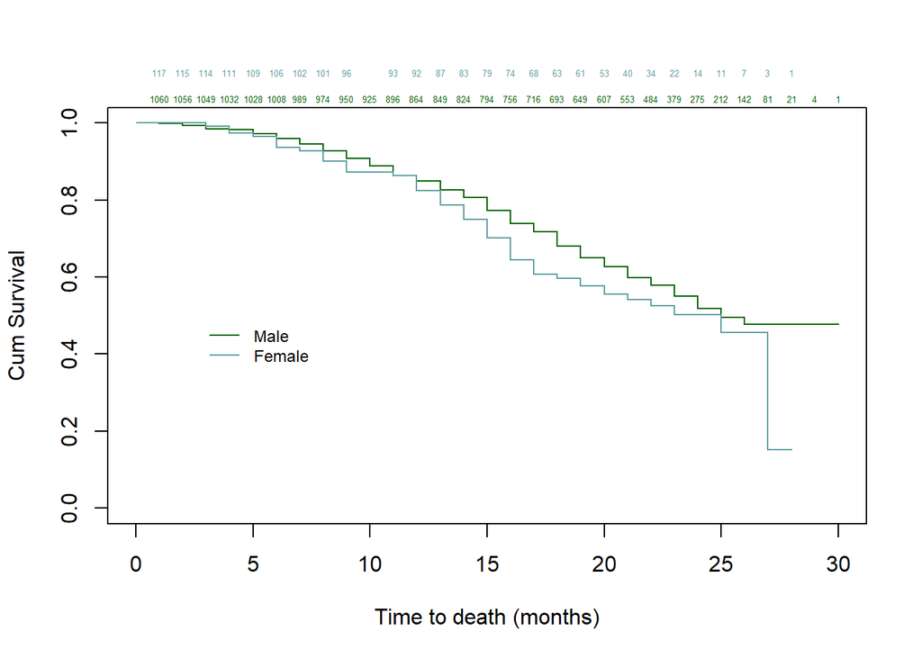

```r
# KM curve plotted with persons in risk
plot(sex.km,
     col = c("darkgreen", "cadetblue"),
     xlab = "Time to death (months)",
     ylab = "Cum Survival")
# Adding the Number at risk in each time interval
mtext(text = sex.km$n.risk[1:30],
      side = 3, at = sex.km$time[1:30],
      cex = .4, col = "darkgreen")
mtext(text = sex.km$n.risk[31:57],
      line = 1, at = sex.km$time[31:57],
      cex = .4, col = "cadetblue")
# and a simple explanatory legend
legend(x = 2.5, y = 0.5, legend = c("Male", "Female"),
       lty = 1, col = c("darkgreen", "cadetblue"),
       bty = "n", cex = .75)
```

```r
# variable - antibiotics
mac$antibiotic<-relevel(mac$antibiotic,ref="combination")
coxmac_ant <- coxph(Surv(dthtime_1m, dthstat) ~ antibiotic, data = mac)
summary(coxmac_ant)
```

```
## Call:
## coxph(formula = Surv(dthtime_1m, dthstat) ~ antibiotic, data = mac)
##
##   n= 1177, number of events= 514
##
##                              coef exp(coef) se(coef)      z Pr(>|z|)
## antibioticrifabutin      -0.08922   0.91465  0.10744 -0.830    0.406
## antibioticclarithromycin -0.11904   0.88777  0.10760 -1.106    0.269
##
##                          exp(coef) exp(-coef) lower .95 upper .95
## antibioticrifabutin         0.9146      1.093     0.741     1.129
## antibioticclarithromycin    0.8878      1.126     0.719     1.096
##
## Concordance= 0.518  (se = 0.013 )
## Likelihood ratio test= 1.33  on 2 df,   p=0.5
## Wald test            = 1.34  on 2 df,   p=0.5
## Score (logrank) test = 1.34  on 2 df,   p=0.5
```

```r
# comparison with log-rank test
survdiff(Surv(dthtime_1m, dthstat) ~ antibiotic, data = mac)
```

```
## Call:
## survdiff(formula = Surv(dthtime_1m, dthstat) ~ antibiotic, data = mac)
##
##                             N Observed Expected (O-E)^2/E (O-E)^2/V
## antibiotic=combination    389      179      167    0.8294    1.2699
## antibiotic=rifabutin      391      168      171    0.0621    0.0962
## antibiotic=clarithromycin 397      167      176    0.4133    0.6482
##
##  Chisq= 1.3  on 2 degrees of freedom, p= 0.5
```

[figure not shown]

```r
# Kaplan Meier Curve for Antibiotics
anti.km <- survfit(Surv(dthtime_1m, dthstat) ~ antibiotic, data = mac)
ggsurvplot(anti.km, legend.labs=c("Rifabutin", "Clarithromycin", "Combination"))
```

[figure not shown]

```r
#KM curve plotted with persons in risk
plot(anti.km,
     col = c("darkgreen", "cadetblue", "slateblue"),
     xlab = "Time to death (months)", ylab = "Cum Survival")
legend(x = 2.5, y = 0.5,
       legend = c("Rifabutin", "Clarithromycin", "Combination"),
       lty = 1, col = c("darkgreen", "cadetblue", "slateblue"),
       bty = "n", cex = .75)
mtext(text = anti.km$n.risk[1:30],
      side = 3, at = anti.km$time[1:30],
      cex = .4, col = "darkgreen")
mtext(text = anti.km$n.risk[31:59],
      line = .5, at = anti.km$time[31:59],
      cex = .4, col = "cadetblue")
mtext(text = anti.km$n.risk[60:87],
      line = 1, at = anti.km$time[60:87],
      cex = .4, col = "slateblue")
```

Evaluating Proportional Hazards (PH) assumption

Graphical

- -log–log survival curves

```r
#1_Proportionality_log-log survival curves against logtime
antib <- Surv(mac$dthtime_1m, mac$dthstat)
antib
```

[output not shown]

[output cut: 51 more lines]

[figure not shown]

```r
plot(survfit(antib ~ mac$antibiotic),
     lty = c(2:4), col = c(8:10),
     fun = "cloglog",
     ylab = "log-log survival",
     xlab = "logtime")
legend(1, 0,
       legend = c("Rifabutin", "Clarithromycin", "Combination"),
       lty = c(2:4), col = c(8:10),
       bty = "n", cex = .75)
```

log-log survival curves should be parallel which is the case here. So the proportionality assumption holds.

- observed versus expected plots

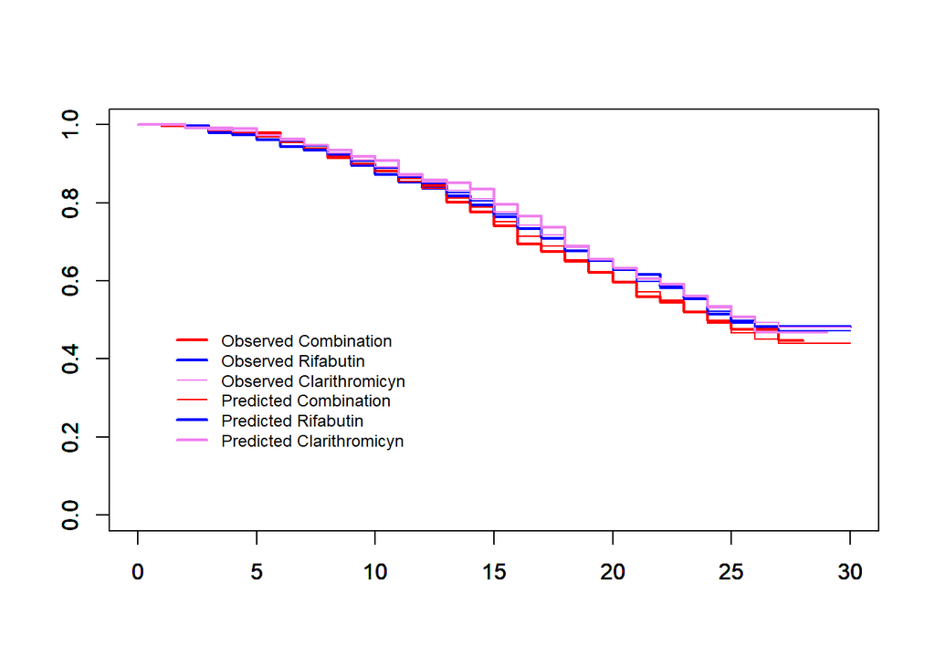

```r
#1_Proportionality_observed_vs_predicted
coxmac.s <- coxph(Surv(dthtime_1m, dthstat) ~ antibiotic, data = mac)
plot(survfit(coxph(Surv(dthtime_1m, dthstat) ~ 1,
                   data = mac,
                   subset = antibiotic == "combination")),
     conf.int = F, col = "red", lwd = 2, xlim=c(0, 30))
par(new = T)
plot(survfit(coxph(Surv(dthtime_1m, dthstat) ~ 1,
                   data = mac,
                   subset = antibiotic == "rifabutin")),
     conf.int = F, col = "blue", lwd = 2, xlim=c(0, 30))
par(new = T)
plot(survfit(coxph(Surv(dthtime_1m, dthstat) ~ 1,
                   data = mac,
                   subset = antibiotic == "clarithromycin")),
     conf.int = F, col = "violet", lwd = 2, xlim=c(0, 30))
par(new = T)
plot(survfit(coxmac.s, newdata = data.frame(antibiotic = "combination")),
     col = "red", conf.int = F, xlim=c(0, 30))
par(new = T)
plot(survfit(coxmac.s, newdata = data.frame(antibiotic="rifabutin"), xlim=c(0, 30)),
     col = "blue", conf.int = F)
par(new = T)
plot(survfit(coxmac.s, newdata = data.frame(antibiotic = "clarithromycin"), xlim=c(0, 30)),
     col = "violet", conf.int = F, xlim=c(0, 30))
legend(1, .5,
       legend = c("Observed Combination", "Observed Rifabutin", "Observed Clarithromicyn",
                  "Predicted Combination", "Predicted Rifabutin", "Predicted Clarithromicyn"),
       lwd = c(2, 2, 1, 1),
       col = c("red", "blue", "violet", "red", "blue", "violet"),
       cex = 0.75, bty = "n")
```

The curves are parallel so the proportionality assumption holds.

```r
# continuous variable - cd4
coxmac <- coxph(Surv(dthtime_1m, dthstat) ~ cd4, data = mac)
summary(coxmac)
```

```
## Call:
## coxph(formula = Surv(dthtime_1m, dthstat) ~ cd4, data = mac)
##
##   n= 1177, number of events= 514
##
##          coef exp(coef)  se(coef)      z Pr(>|z|)
## cd4 -0.011620  0.988447  0.001559 -7.453 9.13e-14 ***
## ---
## Signif. codes:  0 '***' 0.001 '**' 0.01 '*' 0.05 '.' 0.1 ' ' 1
##
##     exp(coef) exp(-coef) lower .95 upper .95
## cd4    0.9884      1.012    0.9854    0.9915
##
## Concordance= 0.62  (se = 0.013 )
## Likelihood ratio test= 67.07  on 1 df,   p=3e-16
## Wald test            = 55.55  on 1 df,   p=9e-14
## Score (logrank) test = 55.31  on 1 df,   p=1e-13
```

Interpretation: The risk of death is reduced by about (0.99-1=-0.01) 1 % as the patient’s CD4 cell count increase by one cell/μL [HR=0.988, 95%CI: (0.985, 0.991), p<0.001].

Checking linearity

```r
# Create categorical variable from cd4 using quantiles.
q <- quantile(mac$cd4, c(0, .25, .5, .75, 1))
# the new categorized cd4 is named VarQ
varQ <- cut(mac$cd4, q, include.lowest = T)
```

We notice that hazard ratios are decreasing with higher quantiles of cd4, so linearity holds.

```r
# Kaplan Meier for varQ
km.q.cd4 <- coxph(Surv(dthtime_1m, dthstat) ~ varQ, data = mac)
km.q.cd4
```

```
## Call:
## coxph(formula = Surv(dthtime_1m, dthstat) ~ varQ, data = mac)
##
##                 coef exp(coef) se(coef)      z        p
## varQ(11,27]  -0.3995    0.6707   0.1141 -3.500 0.000465
## varQ(27,60]  -0.6848    0.5042   0.1194 -5.738 9.61e-09
## varQ(60,299] -1.0411    0.3531   0.1317 -7.902 2.75e-15
##
## Likelihood ratio test=74.36  on 3 df, p=4.97e-16
## n= 1177, number of events= 514
```

```r
# Check variables age and antiret
coxmac_age <- coxph(Surv(dthtime_1m, dthstat) ~ age, data = mac)
summary(coxmac_age)
```

```
## Call:
## coxph(formula = Surv(dthtime_1m, dthstat) ~ age, data = mac)
##
##   n= 1177, number of events= 514
##
##         coef exp(coef) se(coef)     z Pr(>|z|)
## age 0.023711  1.023995 0.004943 4.797 1.61e-06 ***
## ---
## Signif. codes:  0 '***' 0.001 '**' 0.01 '*' 0.05 '.' 0.1 ' ' 1
##
##     exp(coef) exp(-coef) lower .95 upper .95
## age     1.024     0.9766     1.014     1.034
##
## Concordance= 0.562  (se = 0.013 )
## Likelihood ratio test= 22.32  on 1 df,   p=2e-06
## Wald test            = 23.01  on 1 df,   p=2e-06
## Score (logrank) test = 22.99  on 1 df,   p=2e-06
```

```r
coxmac_antiret <- coxph(Surv(dthtime_1m, dthstat) ~ antiret, data = mac)
summary(coxmac_antiret)
```

```
## Call:
## coxph(formula = Surv(dthtime_1m, dthstat) ~ antiret, data = mac)
##
##   n= 1177, number of events= 514
##
##                coef exp(coef) se(coef)      z Pr(>|z|)
## antiretYes -0.20644   0.81348  0.09854 -2.095   0.0362 *
## ---
## Signif. codes:  0 '***' 0.001 '**' 0.01 '*' 0.05 '.' 0.1 ' ' 1
##
##            exp(coef) exp(-coef) lower .95 upper .95
## antiretYes    0.8135      1.229    0.6706    0.9868
##
## Concordance= 0.524  (se = 0.01 )
## Likelihood ratio test= 4.25  on 1 df,   p=0.04
## Wald test            = 4.39  on 1 df,   p=0.04
## Score (logrank) test = 4.4  on 1 df,   p=0.04
```

# Multivariable Cox regression models

```r
multicox <- coxph(Surv(dthtime_1m, dthstat) ~ age + sex + cd4 + antibiotic+antiret, data = mac)
summary(multicox)
```

```
## Call:
## coxph(formula = Surv(dthtime_1m, dthstat) ~ age + sex + cd4 +
##     antibiotic + antiret, data = mac)
##
##   n= 1177, number of events= 514
##
##                               coef exp(coef)  se(coef)      z Pr(>|z|)
## age                       0.025510  1.025838  0.004888  5.219 1.80e-07 ***
## sex1                      0.313953  1.368825  0.145954  2.151   0.0315 *
## cd4                      -0.012069  0.988003  0.001563 -7.723 1.13e-14 ***
## antibioticrifabutin      -0.065132  0.936944  0.107965 -0.603   0.5463
## antibioticclarithromycin -0.130309  0.877824  0.107760 -1.209   0.2266
## antiretYes               -0.179292  0.835861  0.099455 -1.803   0.0714 .
## ---
## Signif. codes:  0 '***' 0.001 '**' 0.01 '*' 0.05 '.' 0.1 ' ' 1
##
##                          exp(coef) exp(-coef) lower .95 upper .95
## age                         1.0258     0.9748    1.0161     1.036
## sex1                        1.3688     0.7306    1.0283     1.822
## cd4                         0.9880     1.0121    0.9850     0.991
## antibioticrifabutin         0.9369     1.0673    0.7583     1.158
## antibioticclarithromycin    0.8778     1.1392    0.7107     1.084
## antiretYes                  0.8359     1.1964    0.6878     1.016
##
## Concordance= 0.643  (se = 0.012 )
## Likelihood ratio test= 103  on 6 df,   p=<2e-16
## Wald test            = 94.39  on 6 df,   p=<2e-16
## Score (logrank) test = 94.17  on 6 df,   p=<2e-16
```

Interpretation (for the first two: age and sex):

For every year increase in age the hazard of death is increased by 1.026 adjusting for all the other variables in the model. [HR=1.026, 95%CI: (1.016, 1.036), p<0.001].

Being female (sex=1) increases the hazard by a factor of 1.368 adjusting for all the other variables in the model. [HR=1.368, 95%CI: (1.028, 1.822), p=0.031]

Goodness of fit test

```r
#2_Goodness-of-fit (GOF) tests /check proportionality
gof.s <- coxph(Surv(dthtime_1m, dthstat) ~ age + sex + cd4 + antiret, data = mac)
gof.s.zph <- cox.zph(gof.s)
gof.s.zph
```

```
##           chisq df     p
## age     0.13421  1 0.714
## sex     0.00834  1 0.927
## cd4     4.41296  1 0.036
## antiret 1.07166  1 0.301
## GLOBAL  5.64957  4 0.227
```

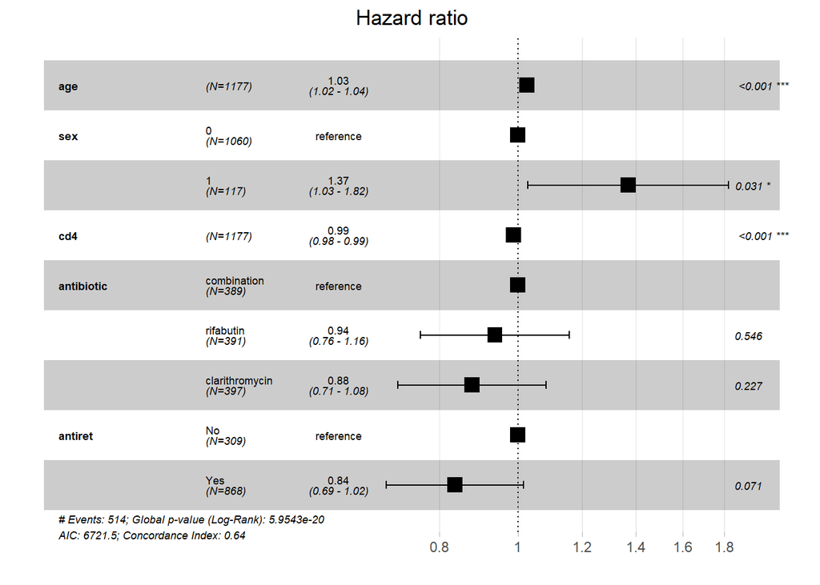

```r
# Forest plot of the results
ggforest(multicox, data=mac, fontsize=0.6)
```

# Parametric survival models

More information on the distribution used in parametric survival modelling can be found here: https://www.r-bloggers.com/2019/06/parametric-survival-modeling/

```r
# Fit an exponential model with cd4 (continuous variable) as an independent parameter
fitExp <- survreg(Surv(dthtime_1m, dthstat) ~ cd4, data = mac, dist = "exponential")
summary(fitExp)
```

```
##
## Call:
## survreg(formula = Surv(dthtime_1m, dthstat) ~ cd4, data = mac,
##     dist = "exponential")
##               Value Std. Error     z      p
## (Intercept) 3.38480    0.06449 52.49 <2e-16
## cd4         0.01018    0.00153  6.64  3e-11
##
## Scale fixed at 1
##
## Exponential distribution
## Loglik(model)= -2414.4   Loglik(intercept only)= -2440.7
##  Chisq= 52.44 on 1 degrees of freedom, p= 4.4e-13
## Number of Newton-Raphson Iterations: 4
## n= 1177
```

```r
exp(coef(fitExp))
```

```
## (Intercept)         cd4
##   29.512019    1.010237
```

```r
exp(confint(fitExp))
```

```
##                 2.5 %    97.5 %
## (Intercept) 26.008096 33.488006
## cd4          1.007206  1.013276
```

Interpretation: For every unit increase of cd4 survival time is extended by 1.010 [95%CI: (1.007,1.013), p<0.001]

```r
# Fit an exponential model with sex (categorical variable) as an independent parameter
fitExp <- survreg(Surv(dthtime_1m, dthstat) ~ sex, data = mac, dist = "exponential")
summary(fitExp)
```

```
##
## Call:
## survreg(formula = Surv(dthtime_1m, dthstat) ~ sex, data = mac,
##     dist = "exponential")
##               Value Std. Error    z      p
## (Intercept)  3.7636     0.0466 80.8 <2e-16
## sex1        -0.1588     0.1450 -1.1   0.27
##
## Scale fixed at 1
##
## Exponential distribution
## Loglik(model)= -2440.1   Loglik(intercept only)= -2440.7
##  Chisq= 1.15 on 1 degrees of freedom, p= 0.28
## Number of Newton-Raphson Iterations: 4
## n= 1177
```

```r
exp(coef(fitExp))
```

```
## (Intercept)        sex1
##  43.1041215   0.8531338
```

```r
exp(confint(fitExp))
```

```
##                 2.5 %    97.5 %
## (Intercept) 39.343627 47.224047
## sex1         0.642033  1.133645
```

Interpretation: Women’s survival time is about 15% slower than in men.

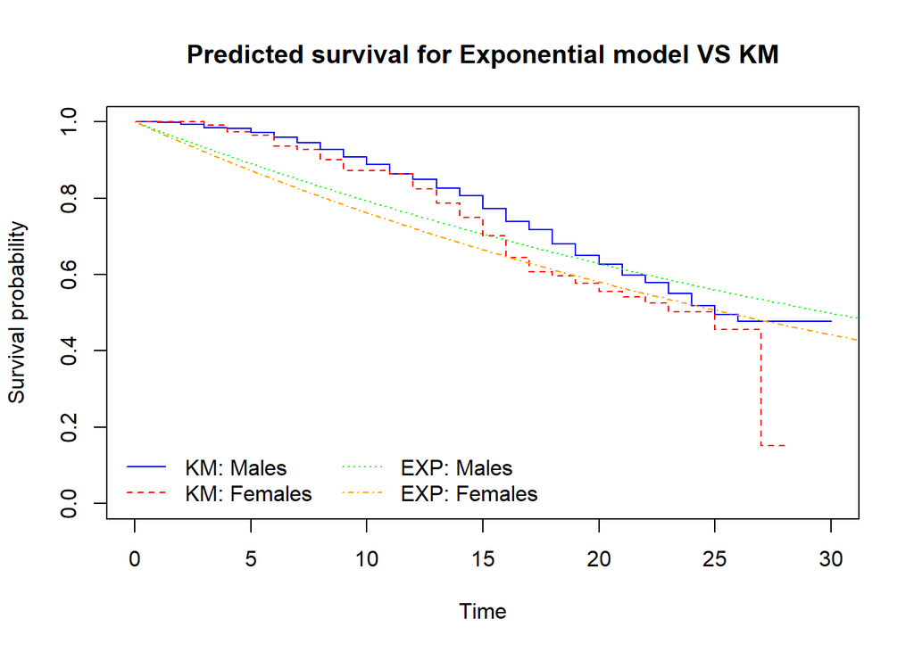

```r
# how well is the fitting of exp model?
# Get the KM estimates and then add the curves fitted by the exponential model
fitKM = survfit( Surv(dthtime_1m, dthstat) ~ sex,data = mac)
plot(fitKM,mark.time = F,main = "Predicted survival for Exponential model VS KM",
     xlab = "Time",ylab = "Survival probability",lty = 1:2,col = c("blue","red"))
pct = seq(0,1,by = 0.001)
lines(predict(fitExp,newdata = data.frame(sex = "0"),type = "quantile",p = pct),1-pct,lty = 3,col = "green")
lines(predict(fitExp,newdata = data.frame(sex = '1'),type = "quantile",p = pct),1-pct,lty = 4,col = "orange")
legend("bottomleft",bty = "n",lty = 1:4,col = c("blue","red","green","orange"),legend = c("KM: Males","KM: Females","EXP: Males","EXP: Females"),ncol = 2)
```

Exponential model does not fit the data well.

We will fit a Weibull model instead

```r
fitWei = survreg( Surv(dthtime_1m, dthstat) ~ sex,data = mac,dist = "weibull")
summary(fitWei)
```

```
##
## Call:
## survreg(formula = Surv(dthtime_1m, dthstat) ~ sex, data = mac,
##     dist = "weibull")
##               Value Std. Error      z      p
## (Intercept)  3.3990     0.0259 131.08 <2e-16
## sex1        -0.1192     0.0709  -1.68  0.093
## Log(scale)  -0.7164     0.0398 -18.01 <2e-16
##
## Scale= 0.489
##
## Weibull distribution
## Loglik(model)= -2315.3   Loglik(intercept only)= -2316.6
##  Chisq= 2.65 on 1 degrees of freedom, p= 0.1
## Number of Newton-Raphson Iterations: 5
## n= 1177
```

```r
exp(coef(fitWei))
```

```
## (Intercept)        sex1
##  29.9351171   0.8876529
```

```r
exp(confint(fitWei))
```

```
##                  2.5 %    97.5 %
## (Intercept) 28.4517717 31.495797
## sex1         0.7725241  1.019939
```

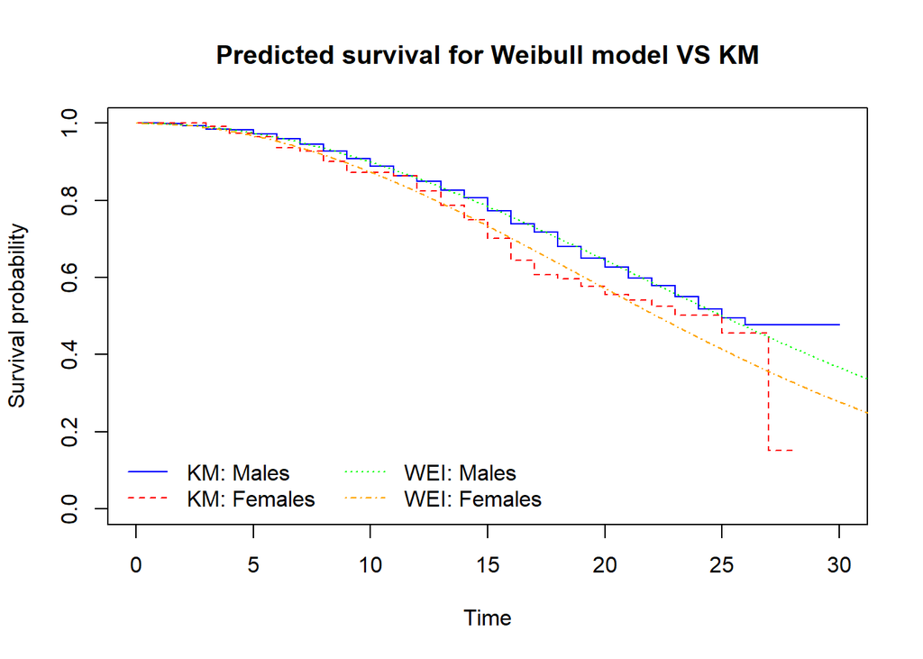

```r
#produce a graph that compares the survival curves predicted by the
#Weibull model with the raw KM survival estimates

plot(fitKM,mark.time = F,main = "Predicted survival for Weibull model VS KM",
     xlab = "Time",ylab = "Survival probability",lty = 1:2,
     col = c("blue","red"))
# Add curves fitted by the Weibull model
pct = seq(0,1,by = 0.001)
lines(predict(fitWei,newdata = data.frame(sex = "0"),type = "quantile",
              p = pct),1-pct,lty = 3,col = "green")
lines(predict(fitWei,newdata = data.frame(sex = "1"),type = "quantile",
              p = pct),1-pct,lty = 4,col = "orange")
legend("bottomleft",bty = "n",lty = 1:4,col = c("blue","red","green","orange"),
       legend = c("KM: Males","KM: Females","WEI: Males","WEI: Females"),ncol = 2)
```

Weibull model fits better our data.

```r
# change the reference group to combination
mac$antibiotic<-relevel(mac$antibiotic,ref="combination")

#Fit an exponential model with antibiotics as an independent variable
fitExp <- survreg(Surv(dthtime_1m, dthstat) ~ antibiotic, data = mac, dist = "exponential")
summary(fitExp)
```

```
##
## Call:
## survreg(formula = Surv(dthtime_1m, dthstat) ~ antibiotic, data = mac,
##     dist = "exponential")
##                           Value Std. Error     z      p
## (Intercept)              3.6892     0.0747 49.36 <2e-16
## antibioticrifabutin      0.0770     0.1074  0.72   0.47
## antibioticclarithromycin 0.1018     0.1076  0.95   0.34
##
## Scale fixed at 1
##
## Exponential distribution
## Loglik(model)= -2440.2   Loglik(intercept only)= -2440.7
##  Chisq= 0.98 on 2 degrees of freedom, p= 0.61
## Number of Newton-Raphson Iterations: 4
## n= 1177
```

```r
exp(coef(fitExp))
```

```
##              (Intercept)      antibioticrifabutin antibioticclarithromycin
##                40.011173                 1.080055                 1.107176
```

```r
exp(confint(fitExp))
```

```
##                               2.5 %    97.5 %
## (Intercept)              34.5588670 46.323682
## antibioticrifabutin       0.8750046  1.333159
## antibioticclarithromycin  0.8966846  1.367078
```

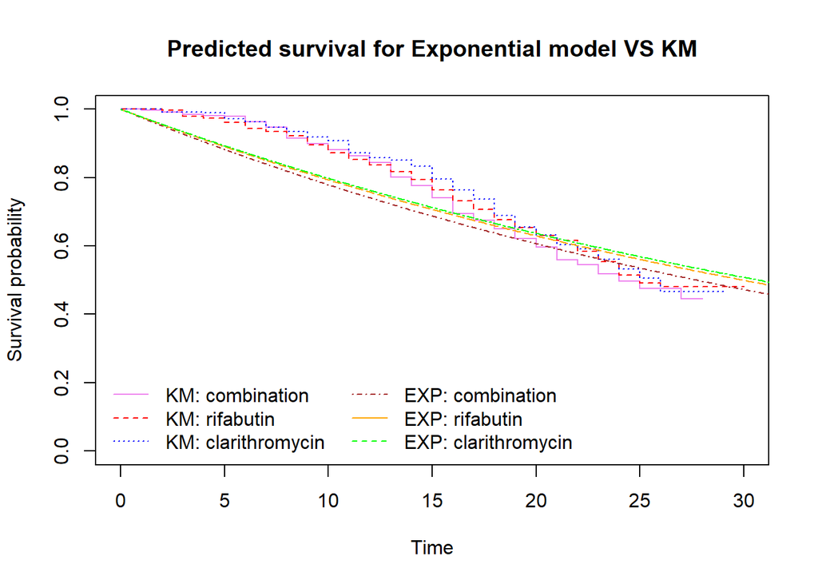

```r
# Get the KM estimates
fitKM = survfit( Surv(dthtime_1m, dthstat) ~ as.factor(antibiotic),data = mac)

plot(fitKM,mark.time = F,main = "Predicted survival for Exponential model VS KM",
     xlab = "Time",ylab = "Survival probability",lty = c(1,2,3),
     col = c("violet","red", "blue"))
# Add the curves fitted by the exponential model
pct = seq(0,1,by = 0.001)
lines(predict(fitExp,newdata = data.frame(antibiotic = "combination"),type = "quantile", p = pct),1-pct,lty = 4,col = "brown")
lines(predict(fitExp,newdata = data.frame(antibiotic = "rifabutin"),type = "quantile",
              p = pct),1-pct,lty = 5,col = "orange")
lines(predict(fitExp,newdata = data.frame(antibiotic = "clarithromycin"),type = "quantile",
              p = pct),1-pct,lty = 6,col = "green")
legend("bottomleft",bty = "n",lty = 1:4,col = c("violet","red", "blue","brown", "orange","green"),
       legend = c("KM: combination","KM: rifabutin", "KM: clarithromycin","EXP: combination","EXP: rifabutin", "EXP: clarithromycin"),ncol = 2)
```

```r
# Fit a weibull model since Exp fit was not adequate
fitWei <- survreg(Surv(dthtime_1m, dthstat) ~ antibiotic, data = mac, dist = "weibull")
summary(fitWei)
```

```
##
## Call:
## survreg(formula = Surv(dthtime_1m, dthstat) ~ antibiotic, data = mac,
##     dist = "weibull")
##                            Value Std. Error      z      p
## (Intercept)               3.3552     0.0383  87.65 <2e-16
## antibioticrifabutin       0.0427     0.0526   0.81   0.42
## antibioticclarithromycin  0.0580     0.0527   1.10   0.27
## Log(scale)               -0.7143     0.0398 -17.97 <2e-16
##
## Scale= 0.49
##
## Weibull distribution
## Loglik(model)= -2316   Loglik(intercept only)= -2316.6
##  Chisq= 1.3 on 2 degrees of freedom, p= 0.52
## Number of Newton-Raphson Iterations: 5
## n= 1177
```

```r
exp(coef(fitWei))
```

```
##              (Intercept)      antibioticrifabutin antibioticclarithromycin
##                28.652346                 1.043580                 1.059701
```

```r
exp(confint(fitWei))
```

```
##                               2.5 %    97.5 %
## (Intercept)              26.5813585 30.884687
## antibioticrifabutin       0.9413494  1.156912
## antibioticclarithromycin  0.9557182  1.174998
```

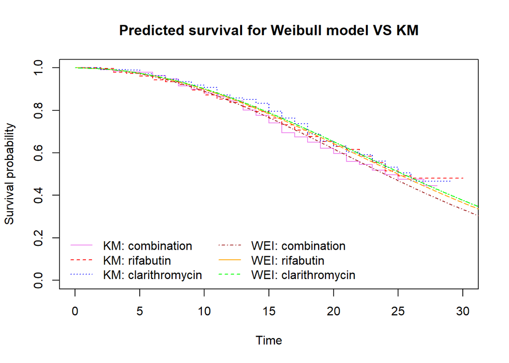

```r
# Make the KM plot
# Get the KM estimates
fitKM = survfit( Surv(dthtime_1m, dthstat) ~ as.factor(antibiotic),data = mac)

plot(fitKM,mark.time = F,main = "Predicted survival for Weibull model VS KM",
     xlab = "Time",ylab = "Survival probability",lty = c(1,2,3),
     col = c("violet","red", "blue"))
# Add the curves fitted by the weibull model
pct = seq(0,1,by = 0.001)

lines(predict(fitWei,newdata = data.frame(antibiotic = "combination"),type = "quantile", p = pct),1-pct,lty = 4,col = "brown")
lines(predict(fitWei,newdata = data.frame(antibiotic = "rifabutin"),type = "quantile",
              p = pct),1-pct,lty = 5,col = "orange")
lines(predict(fitWei,newdata = data.frame(antibiotic = "clarithromycin"),type = "quantile",
              p = pct),1-pct,lty = 6,col = "green")
legend("bottomleft",bty = "n",lty = 1:4,col = c("violet","red", "blue","brown", "orange","green"),
       legend = c("KM: combination","KM: rifabutin", "KM: clarithromycin","WEI: combination","WEI: rifabutin", "WEI: clarithromycin"),ncol = 2)
```

Multivariable Weibull model

```r
multifitWei <- survreg(Surv(dthtime_1m, dthstat) ~ cd4+sex+antibiotic, data = mac, dist = "weibull")
summary(multifitWei)
```

```
##
## Call:
## survreg(formula = Surv(dthtime_1m, dthstat) ~ cd4 + sex + antibiotic,
##     data = mac, dist = "weibull")
##                              Value Std. Error      z       p
## (Intercept)               3.149986   0.043507  72.40 < 2e-16
## cd4                       0.005589   0.000765   7.31 2.8e-13
## sex1                     -0.123721   0.069547  -1.78   0.075
## antibioticrifabutin       0.049821   0.051499   0.97   0.333
## antibioticclarithromycin  0.072136   0.051616   1.40   0.162
## Log(scale)               -0.735631   0.039427 -18.66 < 2e-16
##
## Scale= 0.479
##
## Weibull distribution
## Loglik(model)= -2280.6   Loglik(intercept only)= -2316.6
##  Chisq= 71.98 on 4 degrees of freedom, p= 8.7e-15
## Number of Newton-Raphson Iterations: 5
## n= 1177
```

```r
exp(coef(multifitWei))
```

```
##              (Intercept)                      cd4                     sex1
##               23.3357300                1.0056044                0.8836261
##      antibioticrifabutin antibioticclarithromycin
##                1.0510825                1.0748011
```

```r
exp(confint(multifitWei))
```

```
##                               2.5 %    97.5 %
## (Intercept)              21.4283291 25.412915
## cd4                       1.0040978  1.007113
## sex1                      0.7710280  1.012668
## antibioticrifabutin       0.9501692  1.162713
## antibioticclarithromycin  0.9713869  1.189225
```